# egzaminas

Izabele Vilkinaite

2016 m birÅ¾elis 15 d

```r
library(car)
library(fpp)
library(dynlm)
library(knitr)
library(psych)
library(dplyr)
```

#### 1 uÅ¾duotis

#### 2 uÅ¾duotis

1. DuomenÅ³ apÅ¾valga ir paruoÅ”imas. **(a)**

```r
data = read.csv2(file="data.csv", header = T)
dat = as.data.frame(lapply(data,as.numeric))
attach(dat)
```

IÅ”trintos reikÅ”miÅ³ eilutÄs, kuriuose yra Na, todÄl paÅ”alintos 4 duomenÅ³ eilutÄs ir duomenys iÅ”saugomi `data.csv` faile.

**(b)** IeÅ”koma iÅ”skirÄiÅ³

```r
mod1 = lm(islaidosVaisiams ~ butinosIslaidos + pajamos + rajonoId + atstumasIkiParduotuves, data=dat)
outlierTest(mod1)
```

```
##
## No Studentized residuals with Bonferonni p < 0.05
## Largest |rstudent|:
##      rstudent unadjusted p-value Bonferonni p
## 401 -2.169579           0.030621           NA
```

```r
new.data = dat[-401,]
```

Å ie duomenys bus naudojami tolimesnei analizei.

**(c)**

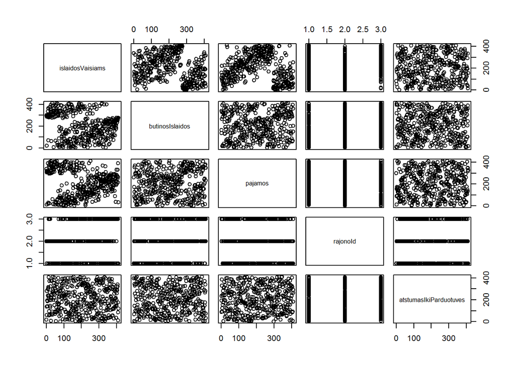

```r
plot(new.data)
```

```r
summary(new.data)
```

```
##  islaidosVaisiams butinosIslaidos    pajamos       rajonoId
##  Min.   :  1      Min.   :  1.0   Min.   :  1   Min.   :1.000
##  1st Qu.:104      1st Qu.:104.0   1st Qu.:104   1st Qu.:1.000
##  Median :206      Median :206.0   Median :206   Median :2.000
##  Mean   :206      Mean   :205.9   Mean   :206   Mean   :1.973
##  3rd Qu.:308      3rd Qu.:308.0   3rd Qu.:308   3rd Qu.:3.000
##  Max.   :410      Max.   :410.0   Max.   :410   Max.   :3.000
##  atstumasIkiParduotuves
##  Min.   :  1.0
##  1st Qu.:103.0
##  Median :205.0
##  Mean   :205.1
##  3rd Qu.:307.0
##  Max.   :410.0
```

```r
cor(new.data)
```

```
##                        islaidosVaisiams butinosIslaidos     pajamos
## islaidosVaisiams             1.00000000   -0.2139711239 -0.08448474
## butinosIslaidos             -0.21397112    1.0000000000  0.09302784
## pajamos                     -0.08448474    0.0930278413  1.00000000
## rajonoId                     0.15207891    0.0180306006 -0.02663263
## atstumasIkiParduotuves      -0.01182112   -0.0002400779  0.05666496
##                           rajonoId atstumasIkiParduotuves
## islaidosVaisiams        0.15207891          -0.0118211174
## butinosIslaidos         0.01803060          -0.0002400779
## pajamos                -0.02663263           0.0566649648
## rajonoId                1.00000000          -0.0140316959
## atstumasIkiParduotuves -0.01403170           1.0000000000
```

Tarp kintamÅ³jÅ³ stiprios koreliacijos nematyti.

**(d)** IÅ”skiriami duomenys ÄÆ du masyvus

```r
trainSet = sample_frac(new.data, 0.8)
sid = as.numeric(rownames(trainSet))
testSet = new.data[-sid,]
```

2. Tiesinio modelio sudarymas  
   **(a)**

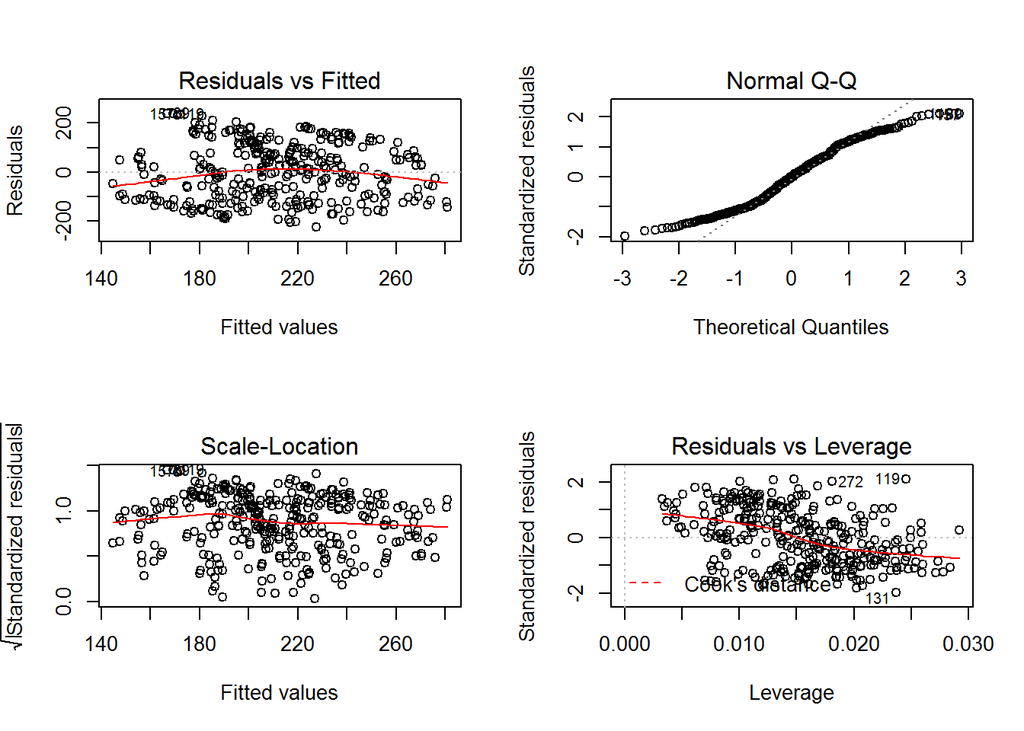

```r
mod2 = lm(islaidosVaisiams ~ butinosIslaidos + pajamos + rajonoId + atstumasIkiParduotuves, data=trainSet)
par(mfrow=c(2,2))
plot(mod2)
```

Matoma, kad modelis yra beveik tiesiÅ”kas.  
**(b)** Tikrinamas duomenÅ³ reikÅ”mingumas.

```r
summary(mod2)
```

```
##
## Call:
## lm(formula = islaidosVaisiams ~ butinosIslaidos + pajamos + rajonoId +
##     atstumasIkiParduotuves, data = trainSet)
##
## Residuals:
##      Min       1Q   Median       3Q      Max
## -224.441 -101.908   -0.901   87.824  238.350
##
## Coefficients:
##                         Estimate Std. Error t value Pr(>|t|)
## (Intercept)            210.93443   25.39950   8.305 2.81e-15 ***
## butinosIslaidos         -0.18690    0.05325  -3.510 0.000512 ***
## pajamos                 -0.04252    0.05432  -0.783 0.434256
## rajonoId                24.75420    7.97307   3.105 0.002074 **
## atstumasIkiParduotuves  -0.01464    0.05244  -0.279 0.780316
## ---
## Signif. codes:  0 '***' 0.001 '**' 0.01 '*' 0.05 '.' 0.1 ' ' 1
##
## Residual standard error: 114.4 on 322 degrees of freedom
## Multiple R-squared:  0.06434,    Adjusted R-squared:  0.05272
## F-statistic: 5.535 on 4 and 322 DF,  p-value: 0.0002543
```

Matoma, kad visÅ³ pirma yra nereikÅ”mingas kintamasis `atstumasIkiParduotuves`, todÄl jÄÆ iÅ”metame.

```r
fit = lm(islaidosVaisiams ~ butinosIslaidos + pajamos + rajonoId, data=trainSet)
summary(fit)
```

```
##
## Call:
## lm(formula = islaidosVaisiams ~ butinosIslaidos + pajamos + rajonoId,
##     data = trainSet)
##
## Residuals:
##      Min       1Q   Median       3Q      Max
## -225.451 -102.086   -2.598   90.210  240.698
##
## Coefficients:
##                  Estimate Std. Error t value Pr(>|t|)
## (Intercept)     207.78844   22.72963   9.142  < 2e-16 ***
## butinosIslaidos  -0.18613    0.05310  -3.505 0.000521 ***
## pajamos          -0.04317    0.05419  -0.797 0.426283
## rajonoId         24.81703    7.95851   3.118 0.001983 **
## ---
## Signif. codes:  0 '***' 0.001 '**' 0.01 '*' 0.05 '.' 0.1 ' ' 1
##
## Residual standard error: 114.2 on 323 degrees of freedom
## Multiple R-squared:  0.06411,    Adjusted R-squared:  0.05542
## F-statistic: 7.376 on 3 and 323 DF,  p-value: 8.55e-05
```

PajamÅ³ kintamasis taip pat nereikÅ”mingas, todÄl taip pat iÅ”metame.

```r
fit1 = lm(islaidosVaisiams ~ butinosIslaidos + rajonoId, data=trainSet)
summary(fit1)
```

```
##
## Call:
## lm(formula = islaidosVaisiams ~ butinosIslaidos + rajonoId, data = trainSet)
##
## Residuals:
##      Min       1Q   Median       3Q      Max
## -217.237 -101.943    0.328   86.770  237.871
##
## Coefficients:
##                  Estimate Std. Error t value Pr(>|t|)
## (Intercept)     198.89270   19.78588  10.052  < 2e-16 ***
## butinosIslaidos  -0.18866    0.05298  -3.561 0.000425 ***
## rajonoId         25.11789    7.94506   3.161 0.001718 **
## ---
## Signif. codes:  0 '***' 0.001 '**' 0.01 '*' 0.05 '.' 0.1 ' ' 1
##
## Residual standard error: 114.1 on 324 degrees of freedom
## Multiple R-squared:  0.06227,    Adjusted R-squared:  0.05649
## F-statistic: 10.76 on 2 and 324 DF,  p-value: 2.994e-05
```

Visi kintamieji reikÅ”mingi, todÄl Å”is modelis bus naudojamas tolimesnei analizei.

**(c)** Patikrinamos modelio savybÄs * Multikolinearumas

```r
vif(fit1)
```

```
## butinosIslaidos        rajonoId
##        1.002958        1.002958
```

Kadangi visi vif < 10, tai modelyje nematoma multikolinearumo problema.

- HeteroskedastiÅ”kumas  
  H0: modelis homoskedastiÅ”kas;  
  H1: modelis heteroskedastiÅ”kas;

```r
ncvTest(fit1)
```

```
## Non-constant Variance Score Test
## Variance formula: ~ fitted.values
## Chisquare = 3.013294    Df = 1     p = 0.08258431
```

Kadangi p-value > 0.05, tai H0 hipotezÄ priimame. Modelis yra homoskedastiÅ”kas.

- PaklaidÅ³ normalumas H0: liekanÅ³ paklaidos yra normalios;  
  H1: liekanÅ³ paklaidos nÄra normalios;

```r
shapiro.test(fit1$res)
```

```
##
##  Shapiro-Wilk normality test
##
## data:  fit1$res
## W = 0.96614, p-value = 6.554e-07
```

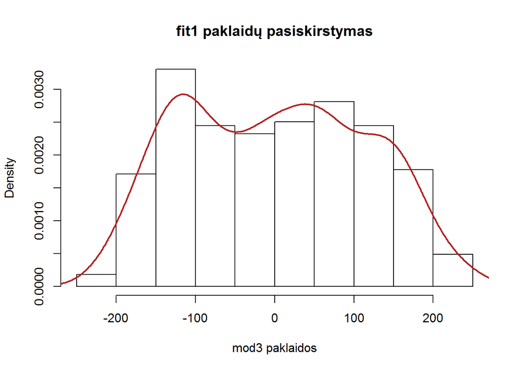

```r
hist(fit1$res, xlab="mod3 paklaidos", main="fit1 paklaidÅ³ pasiskirstymas", probability = T)
lines(density(fit1$res), col="firebrick", lwd=2)
```

Pagal testÄ , kadangi p-value < 0.05, tai H0 hipotezÄ atmetame. Vadinasi modelio paklaidos nÄra normalios, kÄ ÄÆrodo ir iÅ”brÄÅ¾tas grafikas. PasekmÄs: 1) modelyje yra likusi naudinga informacija ir ne visa ji panaudota; 2) modelis nÄra pakankamai āgerasā, galima pagalvoti apie jo tobulinimÄ .

3. Modelio tobulinimas **(a)**

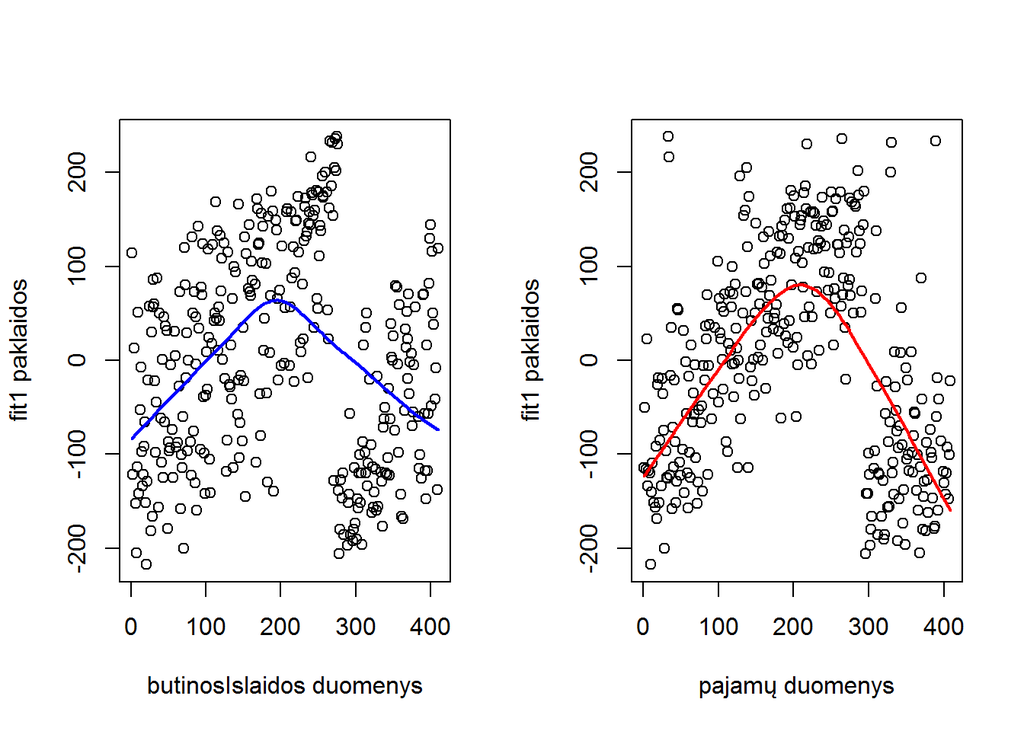

```r
par(mfrow=c(1,2))
plot(trainSet$butinosIslaidos, fit1$res, xlab = "butinosIslaidos duomenys", ylab = "fit1 paklaidos")
lines(lowess(trainSet$butinosIslaidos, fit1$residuals), col="blue", lwd=2)
plot(trainSet$pajamos, fit1$residuals, xlab = "pajamÅ³ duomenys", ylab = "fit1 paklaidos")
lines(lowess(trainSet$pajamos, fit1$residuals), col="red", lwd=2)
```

Matoma, kad abiem atvejais gaunama ne tiesinÄ priklausomybÄ tarp kintamÅ³jÅ³ ir modelio paklaidÅ³.

#### 3 uÅ¾duotis

1. DuomenÅ³ paruoÅ”imas ir apÅ¾valga

```r
dat = M1Germany
data = na.omit(dat)

mod = dynlm(data$logprice ~ L(data$loggnp, 1) + L(data$loggnp, 2), data=data)
# su sezonine komponente nesigauna
```

**(b)**

```r
ser = as.ts(mod$res)
```

**(c)** Tikrinamas liekanÅ³ stacionarumas. Dickey-Fuller testas su hipotezÄmis:  
H0: duomenys nÄra stacionarÅ«s;  
H1: duomenys yra stacionarÅ«s.

```r
adf.test(ser)
```

```
##
##  Augmented Dickey-Fuller Test
##
## data:  ser
## Dickey-Fuller = -1.9575, Lag order = 5, p-value = 0.5942
## alternative hypothesis: stationary
```

Kadangi p-value > 0.05, tai H0 hipotezÄ priimame. Duomenys nÄra stacionarÅ«s, todÄl atliekame skirtumÅ³ operacijas.

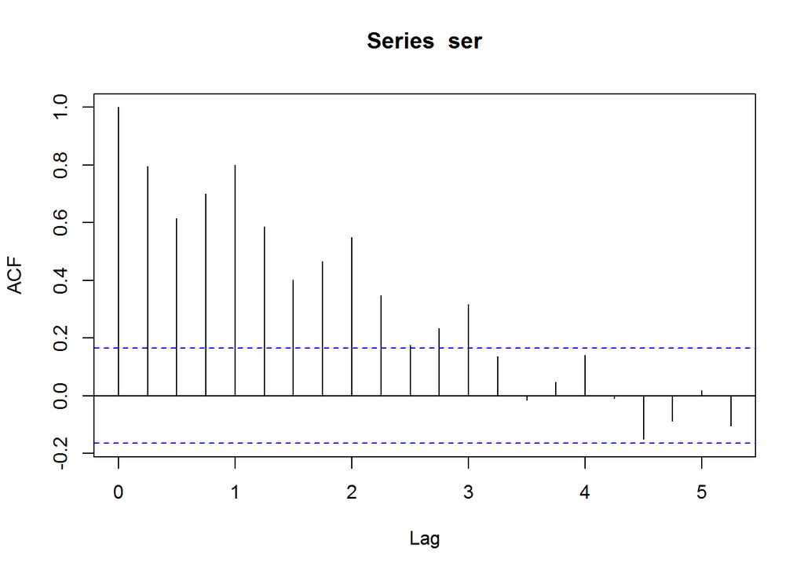

```r
acf(ser) #duomenys sezoniniai
```

```r
ser1 = diff(ser, lag=1)
adf.test(ser1, alternative = "stationary")
```

```
##
##  Augmented Dickey-Fuller Test
##
## data:  ser1
## Dickey-Fuller = -4.411, Lag order = 5, p-value = 0.01
## alternative hypothesis: stationary
```

Kadangi p-value < 0.05, tai H0 hipotezÄ atmetame - paklaidos yra stacionarios.

**(d)**

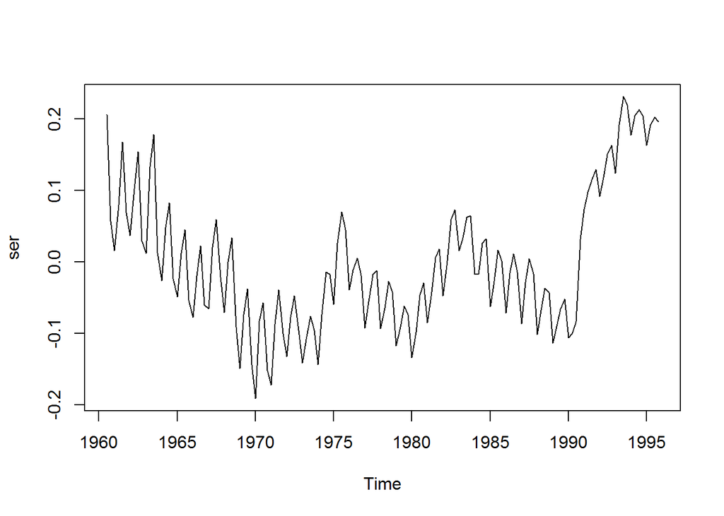

```r
plot(ser)
```

Transformacijos taikyti nÄra tikslo, kadangi duomenys yra nevienodai kintantys laike, nevienodi Å”uoliai.

2. Modeliavimas **(a)**

```r
mod1 = ets(ser)
```

**(b)**

**(c)**

```r
mod3 = auto.arima(ser)
```